# Statistical Inference Project Part 2

## 0.1 Synopsis

This is the project for the statistical inference class. This is the second part of the project which is an analysis of the ToothGrowth data.

In the second portion of the class, I am going to analyze the ToothGrowth data in the R datasets package.

## 0.2 Data Description

The response is the length of odontoblasts (teeth) in each of 10 guinea pigs at each of three dose levels of Vitamin C (0.5, 1, and 2 mg) with each of two delivery methods (orange juice or ascorbic acid).

[,1] len numeric Tooth length  
[,2] supp factor Supplement type (VC or OJ).  
[,3] dose numeric Dose in milligrams.  
*(source: R Doumentation)*

## 0.3 Data Processing

### 0.3.1 Loading packages and libraries

```r
library(ggplot2)
library(datasets)
library(reshape2)
library(dplyr)
```

### 0.3.2 Loading dataset

```r
toothGrowth = tbl_df(ToothGrowth)
```

## 0.4 Anaylsis

### 0.4.1 Summarizing Data

```r
glimpse(toothGrowth)
```

```
## Variables:
## $ len  (dbl) 4.2, 11.5, 7.3, 5.8, 6.4, 10.0, 11.2, 11.2, 5.2, 7.0, 16....
## $ supp (fctr) VC, VC, VC, VC, VC, VC, VC, VC, VC, VC, VC, VC, VC, VC, ...
## $ dose (dbl) 0.5, 0.5, 0.5, 0.5, 0.5, 0.5, 0.5, 0.5, 0.5, 0.5, 1.0, 1....
```

```r
summary(toothGrowth)
```

```
##       len        supp         dose
##  Min.   : 4.20   OJ:30   Min.   :0.500
##  1st Qu.:13.07   VC:30   1st Qu.:0.500
##  Median :19.25           Median :1.000
##  Mean   :18.81           Mean   :1.167
##  3rd Qu.:25.27           3rd Qu.:2.000
##  Max.   :33.90           Max.   :2.000
```

```r
head(toothGrowth,3); tail(toothGrowth,3)
```

```
## Source: local data frame [3 x 3]
##
##    len supp dose
## 1  4.2   VC  0.5
## 2 11.5   VC  0.5
## 3  7.3   VC  0.5
```

```
## Source: local data frame [3 x 3]
##
##     len supp dose
## 58 27.3   OJ    2
## 59 29.4   OJ    2
## 60 23.0   OJ    2
```

### 0.4.2 Exploratory Data Analysis

#### 0.4.2.1 Tooth length vs supplement type

Fisrt, I will explore the relaion between the supplement type and the lenth of tooth

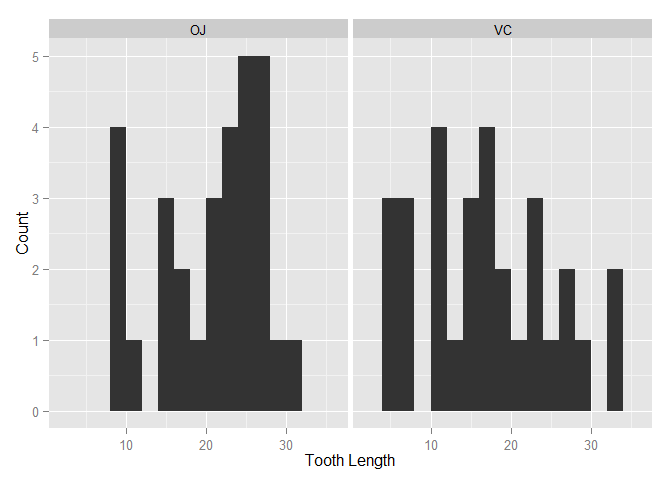

```r
ggplot(data=toothGrowth, aes(x=len)) +
  geom_histogram(binwidth=2) +
  facet_grid( . ~ supp) +
  xlab("Tooth Length") +
  ylab("Count")
```

It seems that both supplements have similar effects on the length of tooth, however, the orange juice, OJ, has more profound effect on most of the teeth

#### 0.4.2.2 Tooth length vs dosage

I will then explore the effect of the dosage quantity on the length of the tooth while examinning this effect for both of the supplements.

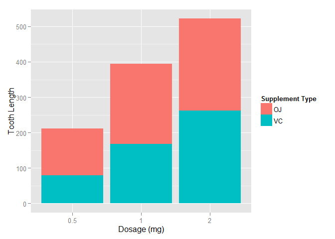

```r
ggplot(data=toothGrowth, aes(x=as.factor(dose), y=len, fill=supp)) +
  geom_bar(stat="identity") +
  xlab("Dosage (mg)") +
  ylab("Tooth Length") +
  guides(fill=guide_legend(title="Supplement Type"))
```

As the dosage increases so does the length of the tooth, however, again the orange juice, the OJ supplement has a stronger effect on the tooth length.

### 0.4.3 Comparison of tooth growth by supp and dose

#### 0.4.3.1 Groups based on supplement

##### 0.4.3.1.1 Extracting Groups

```r
oj= subset(toothGrowth, supp=="OJ")$len
vc= subset(toothGrowth, supp=="VC")$len
```

##### 0.4.3.1.2 Are groups of different variance ?

```r
var(oj);var(vc)
```

```
## [1] 43.63344
```

```
## [1] 68.32723
```

The variance is different for all groups created based on supplement

##### 0.4.3.1.3 Comparing the supplement groups using T Test

```r
test= t.test(len ~ supp, paired = FALSE, val.equal = FALSE, data = toothGrowth)
```

The p-value is 0.0606345 and the 95% confidence interval is -0.1710156, 7.5710156 which suggests that there is no substantial difference between the tooth growth of those subjected to the two types of supplements, namely, OJ and VC, regardless of the dosage.

#### 0.4.3.2 Groups based on supplement and dosage

##### 0.4.3.2.1 Extracting Groups

```r
oj05= subset(toothGrowth, dose ==0.5 & supp=="OJ")$len
oj1= subset(toothGrowth, dose ==1 & supp=="OJ")$len
oj2= subset(toothGrowth, dose ==2 & supp=="OJ")$len


vc05= subset(toothGrowth, dose ==0.5 & supp=="VC")$len
vc1= subset(toothGrowth, dose ==1 & supp=="VC")$len
vc2= subset(toothGrowth, dose ==2 & supp=="VC")$len
```

##### 0.4.3.2.2 Are groups of different variance ?

```r
var(oj05);var(oj1);var(oj2)
```

```
## [1] 19.889
```

```
## [1] 15.29556
```

```
## [1] 7.049333
```

```r
var(vc05);var(vc1);var(vc2)
```

```
## [1] 7.544
```

```
## [1] 6.326778
```

```
## [1] 23.01822
```

The variance is different for all groups created based on supplement and dosage

##### 0.4.3.2.3 Comparing the supplement groups using T Test

```r
testOJ05_1= t.test(x= oj1, y=oj05,  val.equal = FALSE)
testOJ05_1$p.value; testOJ05_1$conf.int
```

```
## [1] 8.784919e-05
```

```
## [1]  5.524366 13.415634
## attr(,"conf.level")
## [1] 0.95
```

```r
testOJ1_2= t.test(x= oj2, y=oj1,  val.equal = FALSE)
testOJ1_2$p.value; testOJ1_2$conf.int
```

```
## [1] 0.03919514
```

```
## [1] 0.1885575 6.5314425
## attr(,"conf.level")
## [1] 0.95
```

```r
testOJ05_2= t.test(x= oj2, y=oj05,  val.equal = FALSE)
testOJ05_2$p.value; testOJ05_2$conf.int
```

```
## [1] 1.323784e-06
```

```
## [1]  9.324759 16.335241
## attr(,"conf.level")
## [1] 0.95
```

#### 0.4.3.3 Groups based on dosage

##### 0.4.3.3.1 Extracting Groups

```r
dose05_1= subset(toothGrowth, dose ==0.5|dose ==1)
dose05_1$supp = NULL
dose1_2= subset(toothGrowth, dose ==1|dose ==2 )
dose1_2$supp = NULL
dose05_2= subset(toothGrowth, dose ==0.5|dose ==2)
dose05_2$supp = NULL
```

##### 0.4.3.3.2 Are groups of different variance ?

```r
var(dose05_1);var(dose1_2);var(dose05_2)
```

```
##            len       dose
## len  40.736000 1.17051282
## dose  1.170513 0.06410256
```

```
##            len      dose
## len  26.825583 1.6320513
## dose  1.632051 0.2564103
```

```
##            len      dose
## len  78.366660 5.9596154
## dose  5.959615 0.5769231
```

The variance is different for all groups created based on dosage

##### 0.4.3.3.3 Comparing the supplement groups using T Test

```r
testD05_1= t.test(len ~ dose, paired = FALSE, val.equal = FALSE, data = dose05_1)
testD05_1$p.value; testD05_1$conf.int
```

```
## [1] 1.268301e-07
```

```
## [1] -11.983781  -6.276219
## attr(,"conf.level")
## [1] 0.95
```

```r
testD1_2= t.test(len ~ dose, paired = FALSE, val.equal = FALSE, data = dose1_2)
testD1_2$p.value; testD1_2$conf.int
```

```
## [1] 1.90643e-05
```

```
## [1] -8.996481 -3.733519
## attr(,"conf.level")
## [1] 0.95
```

```r
testD05_2= t.test(len ~ dose, paired = FALSE, val.equal = FALSE, data = dose05_2)
testD05_2$p.value; testD05_2$conf.int
```

```
## [1] 4.397525e-14
```

```
## [1] -18.15617 -12.83383
## attr(,"conf.level")
## [1] 0.95
```

## 0.5 Assumptions and conclusions

[output not shown]